# Binomial Distribution

## 1. Tổng quan :

Nếu các biến X tuân theo luật phân phối nhị thức với parameter :

- n ∈ ℕ (n là số lượng phép thử, ℕ số lần lặp lại phép thử)
- p ∈ [0,1] : p xác xuất True or False
- k : Số lần thành công trong n phép thử đó.

#### Kí hiệu : X ~ B(n, p). B viết tắt Binomial

Ví dụ : Tung 5 đồng xu (n = 5), xác xuất xuất hiện mặt trước và sau là như nhau (p = 0.5), ta thu được 2 đồng sấp, 3 đồng ngữa. Gọi k là số mặt ngữa, ta có k = 2.

Thực hiện việc tung 5 đồng xu trên 100 lần (N = 100), ta thu được tập k chứa các phần tử có giá trị p ∈ [0,5].

## 2. Probability

Xác xuất để có k lần thành công : \begin{equation*} Pr(X=k) = C{n \choose k} p^k (1-p)^{ n-k} \end{equation*}

Với k = 0,1,2,...,n thì : (combinaisons - Tổ hợp) \begin{equation*} C{n \choose k} = \frac{n!}{k!(n-k)!} \end{equation*}

```python
import numpy as np
import pandas as pd
from scipy.stats import binom
import matplotlib.pyplot as plt
```

## 3. Công thức

Trong đó :

- Factoria : Function giai thừa
- Combinasisons : Function tính tổ hợp
- Pr_Binomail : Function tính xác suất thành công với (n : số phép thử mỗi lần, p : Xác xuất thành công, k : số thành công)

```python
# factorial - Giai thừa
def factoria(n):
    x = 1
    if n==0:
        return 1
    for i in range(n):
        x = x * (i+1)
    return x

# Combinaisons - Tổ hợp
# Từ 1 hộp 4 viên xanh đỏ tím vàng, có bao nhiêu cách lấy ra 2 viên, biết (xanh đỏ) (đỏ xanh) là một
def combinaisons(n, k):
    return (factoria(n) / ((factoria(k) * (factoria(n-k)))))

# Probability
def pr_binomial(n, p, k):
    '''
        n : Số phép thử trong 1 lần
        p : Xác xuất thành công mỗi phép thử
        k : Số lần thanahf công trong mỗi phép thử
    '''
    return combinaisons(n, k) * np.power(p,k) * np.power(1-p, n-k)
```

## 4. Example

### 4.1 Example 1 : Tung 1 đồng xu với xác xuất 0.5

Tạo Sample Data đếm số mặt sấp và ngữa khi tung 1 đồng xu.

Trong đó :

- n = 1. (Tung1 đồng xu)
- p = 0,5 Xác xuất xuất hiện 2 mặt là như nhau
- N = 1000. Thực hiện 1000 phép thử

K có 2 giá trị :

- 0 : không có mặt ngữa nào xuất hiện
- 1 : Có 1 mặt ngữa xuất hiện

【ASK】Tính xác xuất :

- Pr(0)
- Pr(1)

```python
N = 1000
sample = pd.DataFrame(np.random.binomial(n = 1, p = 0.5, size = N), columns=['count'])
sample['temp'] = [1] * len(sample)
```

#### 4.1.1 Tập data ghi lại kết quả sau mỗi lần tung đồng xu

```python
pd.DataFrame(sample['count'].head())
```

|  | count |
| --- | --- |
| 0 | 0 |
| 1 | 1 |
| 2 | 1 |
| 3 | 0 |
| 4 | 0 |

#### 4.1.2 Xác xuất được tính theo data

```python
sample.groupby('count').count()/N
```

| count | temp |
| --- | --- |
| 0 | 0.5 |
| 1 | 0.5 |

```
Xác xuất xuất hiện K = 0 và K = 1 là như nhau = 0.5
```

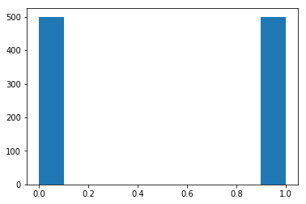

```python
print('Xác xuất xuất hiện K = 0 và K = 1 là như nhau = 0.5')
plt.hist(sample['count'])
```

#### 4.1.3 Xác xuất tính theo công thức

```python
# n = 1 , p = 0.5, k = 1)

print('Xác xuất suất hiện mặt ngữa là : '+str(pr_binomial(1, 0.5, 1)))
```

```
Xác xuất suất hiện mặt ngữa là : 0.5
```

### 4.2 Example 2 : Tung 5 đồng xu với xác xuất 0.5

Trong đó :

- n = 5. (Tung 5 đồng xu)
- p = 0,5 Xác xuất xuất hiện 2 mặt là như nhau
- N = 1000. Thực hiện 1000 phép thử

- 0 : không có mặt ngữa nào xuất hiện
- 1 : Có 1 mặt ngữa xuất hiện
- 2 : Có 2 mặt ngữa xuất hiện
- 3 : Có 3 mặt ngữa xuất hiện
- 4 : Có 4 mặt ngữa xuất hiện
- 5 : Có 5 mặt ngữa xuất hiện

【ASK】Tính xác xuất :

- Pr(k = 0)
- Pr(k = 1)
- Pr(k = 2)
- Pr(k = 3)
- Pr(k = 4)
- Pr(k = 5)

```python
N = 1000
sample1 = pd.DataFrame(np.random.binomial(n = 5, p = 0.5, size = N), columns = ['count'])
sample1['temp'] = [1] * len(sample1)
```

#### 4.2.1 Tập data ghi lại kết quả sau mỗi lần tung đồng xu

```python
pd.DataFrame(sample1['count'][0:10])
```

|  | count |
| --- | --- |
| 0 | 1 |
| 1 | 3 |
| 2 | 1 |
| 3 | 5 |
| 4 | 3 |
| 5 | 2 |
| 6 | 3 |
| 7 | 2 |
| 8 | 2 |
| 9 | 3 |

#### 4.1.2 Xác xuất được tính theo data

```python
sample1.groupby('count').count()/N
```

| count | temp |
| --- | --- |
| 0 | 0.047 |
| 1 | 0.174 |
| 2 | 0.306 |
| 3 | 0.308 |
| 4 | 0.134 |
| 5 | 0.031 |

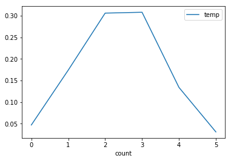

```python
(sample1.groupby('count').count()/N).plot()
```

#### 4.1.3 Xác xuất tính theo công thức

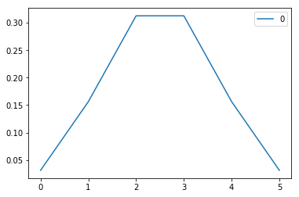

```python
pr = []
for i in range(6):
    pr.append(pr_binomial(5, 0.5, i))

pd.DataFrame(pr).plot()
```

#### So sánh xác xuất được tính dựa vào data thực tế và xác xuất dựa vào công thức, ta thấy kết quả xấp xỉ nhau

```python
print('Kết quả được tính dựa theo công thức : ')
pd.DataFrame(pr)
```

|  | 0 |
| --- | --- |
| 0 | 0.03125 |
| 1 | 0.15625 |
| 2 | 0.31250 |
| 3 | 0.31250 |
| 4 | 0.15625 |
| 5 | 0.03125 |

```python
print('Kết quả được tính dựa vào data : ')
sample1.groupby('count').count()/N
```

```
Kết quả được tính dựa vào data :
```

| count | temp |
| --- | --- |
| 0 | 0.047 |
| 1 | 0.174 |
| 2 | 0.306 |
| 3 | 0.308 |
| 4 | 0.134 |
| 5 | 0.031 |

### 4.3 Example 3 : Tung 5 đồng xu với xác xuất 0.3

#### Assumptions : Đồng xu không đều, mặt sấp xuất hiện ít hơn mặt ngữa. Xác xuất xuất hiện mặt sấp là 0.3

Trong đó :

- 0 : không có mặt ngữa nào xuất hiện
- 1 : Có 1 mặt ngữa xuất hiện
- 2 : Có 2 mặt ngữa xuất hiện
- 3 : Có 3 mặt ngữa xuất hiện
- 4 : Có 4 mặt ngữa xuất hiện
- 5 : Có 5 mặt ngữa xuất hiện

【ASK】Tính xác xuất :

- Pr(k = 0)
- Pr(k = 1)
- Pr(k = 2)
- Pr(k = 3)
- Pr(k = 4)
- Pr(k = 5)

```python
sample4 = pd.DataFrame(np.random.binomial(n = 5, p = 0.3, size = N), columns = ['count'])
sample4['temp'] = [1] * len(sample4)
```

## Analytics :

Từ đồ thị, thấy rằng xác xuất xuất hiện mặt sấp = 1 trong 5 lần tung là cao nhất.

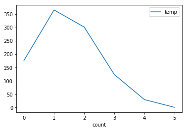

```python
sample4.groupby('count').count().plot()
```

```python
print('Xác xuất tính theo data : ')
sample4.groupby('count').count()/N
```

```
Xác xuất tính theo data :
```

| count | temp |
| --- | --- |
| 0 | 0.177 |
| 1 | 0.366 |
| 2 | 0.302 |
| 3 | 0.124 |
| 4 | 0.030 |
| 5 | 0.001 |

```python
print('Xác xuất tính theo công thức : ')
pr = []
for i in range(6):
    pr.append(pr_binomial(5, 0.3, i))

pd.DataFrame(pr)
```

```
Xác xuất tính theo công thức :
```

|  | 0 |
| --- | --- |
| 0 | 0.16807 |
| 1 | 0.36015 |
| 2 | 0.30870 |
| 3 | 0.13230 |
| 4 | 0.02835 |
| 5 | 0.00243 |

## 5. Example from Real world

Bài toán thực tế :

Dây chuyển sản xuất Iphone gồm 10 Robot, cứ mỗi giờ tình trạng của Robot được update với Status [Hỏng, Chạy tốt]

- Xác xuất một máy có khả năng hỏng mỗi giờ 10%.

Tìm xác xuất các trường hợp sau :

- TH1. Một máy hỏng
- TH2. 2 máy hỏng cùng lúc
- TH3. 3 máy hỏng cùng lúc
- TH4. 4 máy hỏng cùng lúc ....
- TH10. 10 máy hỏng cùng lúc